[figure not shown]

This website accompanies the Psychology of Swearing talk held on Friday 30th August 2019 as part of the University of Glasgow Short Course series.

## Reading list

If you would like more information about anything presented in this talk, I recommend the following sources:

**Books**

- Benjamin Bergen – What the F: What Swearing Reveals About Our Language, Our Brains, and Ourselves. [Amazon link.](https://www.amazon.co.uk/What-Swearing-Reveals-Language-Ourselves/dp/0465060919/ref=sr_1_1?keywords=what+the+f&qid=1566551272&s=gateway&sr=8-1)
- Steven Pinker - The Stuff of Thought. [Amazon link.](https://www.amazon.co.uk/Stuff-Thought-Language-Window-Nature/dp/0141015470/ref=sr_1_1?keywords=stuff+of+thought&qid=1566551312&s=books&sr=1-1)
- Emma Byrne - Swearing is Good For You. Amazon link.

**Websites**

https://stronglang.wordpress.com/  
https://twitter.com/stronglang

**Journal papers**

Where possible I’ve tried to use open-access links but if you run into paywall issues, e-mail emily.nordmann@glasgow.ac.uk and I’ll send you a copy.

[Feldman, G., Lian, H., Kosinski, M., & Stillwell, D. (2017) Frankly, we do give a damn: The relationship between profanity and honesty. Social Psychological and Personality Science](https://journals.sagepub.com/doi/pdf/10.1177/1948550616681055)

[Harris, C. L., Aycicegi, A., & Gleason, J. B. (2003). Taboo words and reprimands elicit greater autonomic reactivity in a first language than in a second language. Applied Psycholinguistics, 24(04), 561-579.](http://www.bu.edu/psych/charris/papers/BilingualTaboo.pdf)

[Jay, T. (2009). The utility and ubiquity of taboo words. Perspectives on Psychological Science, 4(2), 153-161.](https://journals.sagepub.com/doi/pdf/10.1111/j.1745-6924.2009.01115.x?casa_token=A7WjxTkaJ64AAAAA:Xf81MCDxjccBGgUjvQgvd_yhJrSyiCOIwR_EZvXYGQQbUtZBOdbIzpHb794LydeBbeYBARUaTGI)

[Jay, T., & Janschewitz, K. (2008). The pragmatics of swearing. Journal of Politeness Research. Language, Behaviour, Culture, 4(2), 267-288.](http://mcla.edu/Assets/MCLA-Files/Academics/Undergraduate/Psychology/Pragmaticsofswearing.pdf)

[Jay, K. L., & Jay, T. B. (2013). A child’s garden of curses: A gender, historical, and age-related evaluation of the taboo lexicon. The American Journal of Psychology, 126(4), 459-475.](https://www.jstor.org/stable/pdf/10.5406/amerjpsyc.126.4.0459.pdf?casa_token=nSA0bVdGjUgAAAAA:Rr0kY0ga3Y7kmWf_UurgmWbcdTmevy3ZvKjCP0El6TpfLgjmWAYduNAGUGv0suEJtx2sFO4b70to8T2PNWkFlqUoysi4OH3EXIx9k0Q0fNKqlFiQAw)

[Jay, K. L., & Jay, T. B. (2015). Taboo word fluency and knowledge of slurs and general pejoratives: deconstructing the poverty-of-vocabulary myth. Language Sciences, 52, 251-259.](https://mcla.edu/Assets/MCLA-Files/Academics/Undergraduate/Psychology/fluency%202015.pdf)

[Mackay, D. G., Shafto, M., Taylor, J. K., Marian, D. E., Abrams, L., & Dyer, J. R. (2004). Relations between emotion, memory, and attention: Evidence from taboo Stroop, lexical decision, and immediate memory tasks. Memory & Cognition, 32(3), 474-488.](https://link.springer.com/content/pdf/10.3758/BF03195840.pdf)

Stephens, R., Atkins, J., & Kingston, A. (2009). Swearing as a response to pain. Neuroreport, 20(12), 1056-1060.

[Van Lancker, D., & Cummings, J. L. (1999). Expletives: Neurolinguistic and neurobehavioral perspectives on swearing. Brain research reviews, 31(1), 83-104.](https://steinhardt.nyu.edu/scmsAdmin/media/users/drv1/1999_Expletives_neurolinguistic_and_neurobehavioral_persp.pdf)

## Relationship between age and vocabulary

The correlation between age and animals is r = -0.3, p = 0.124.

The correlation between age and swears is r = -0.51, p = 0.012.

The correlation between swears and animals is r = 0.55, p = 0.004.

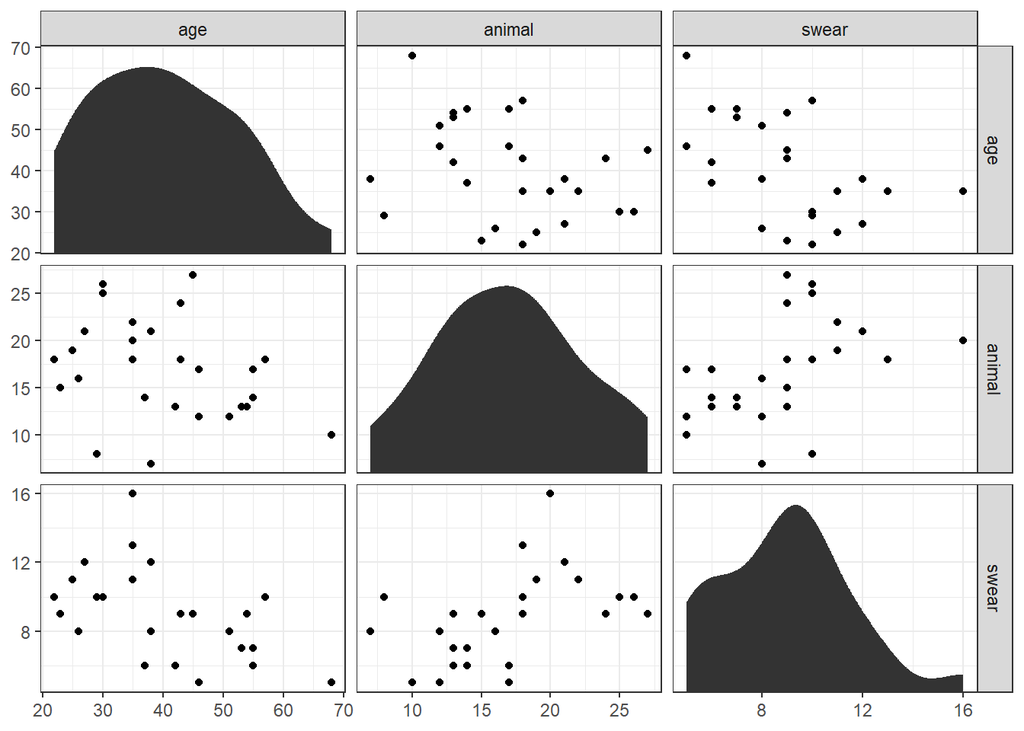

## Vocabulary scores by gender

### General fluency

| gender | average_score |
| --- | --- |
| Man | 14.67 |
| Woman | 17.17 |
| Other | 15.00 |

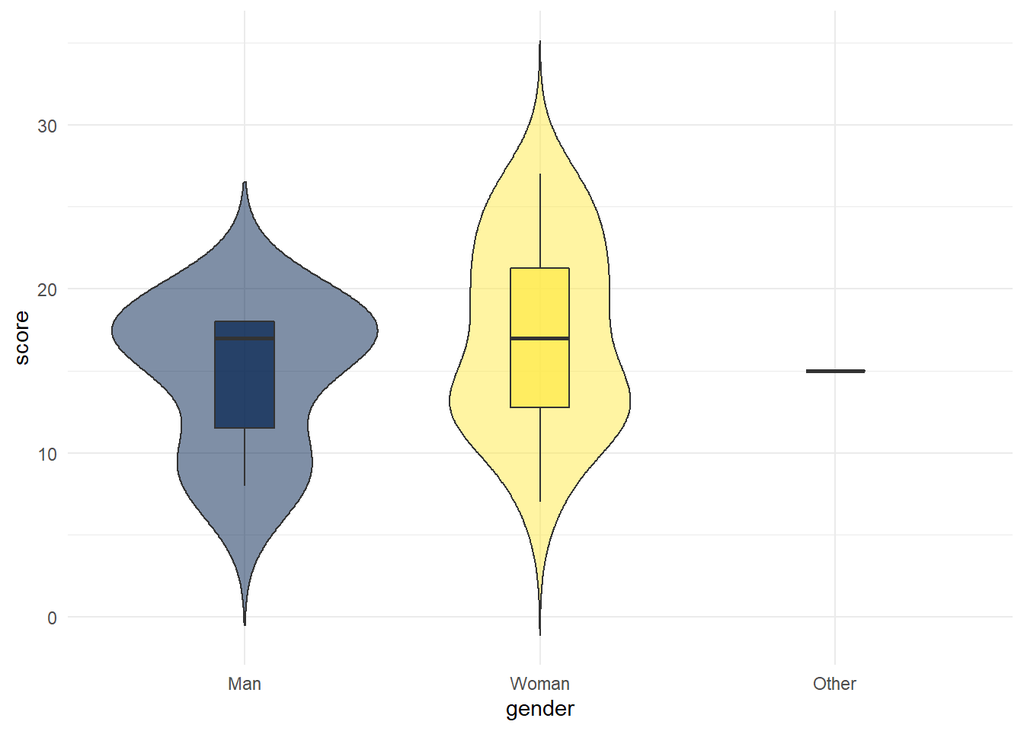

### Swearing

| gender | average_score |
| --- | --- |
| Man | 8.67 |
| Woman | 8.92 |
| Other | 9.00 |

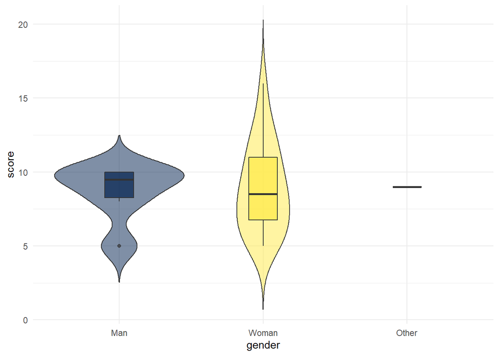

## Most frequent swear words

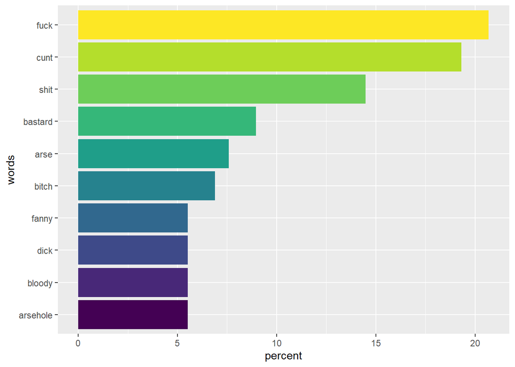

## Word cloud

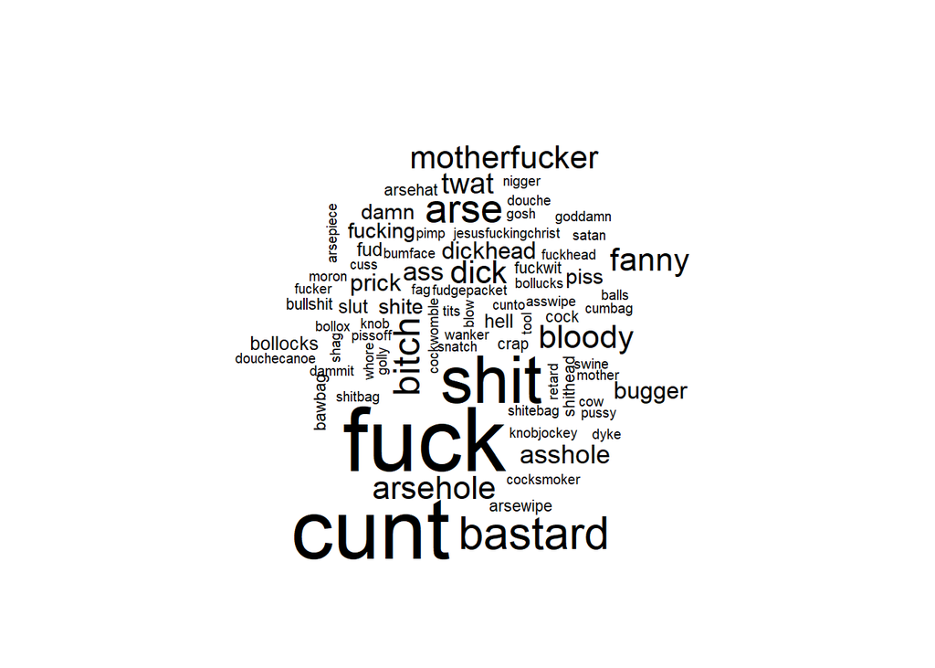

## Most frequent words by gender

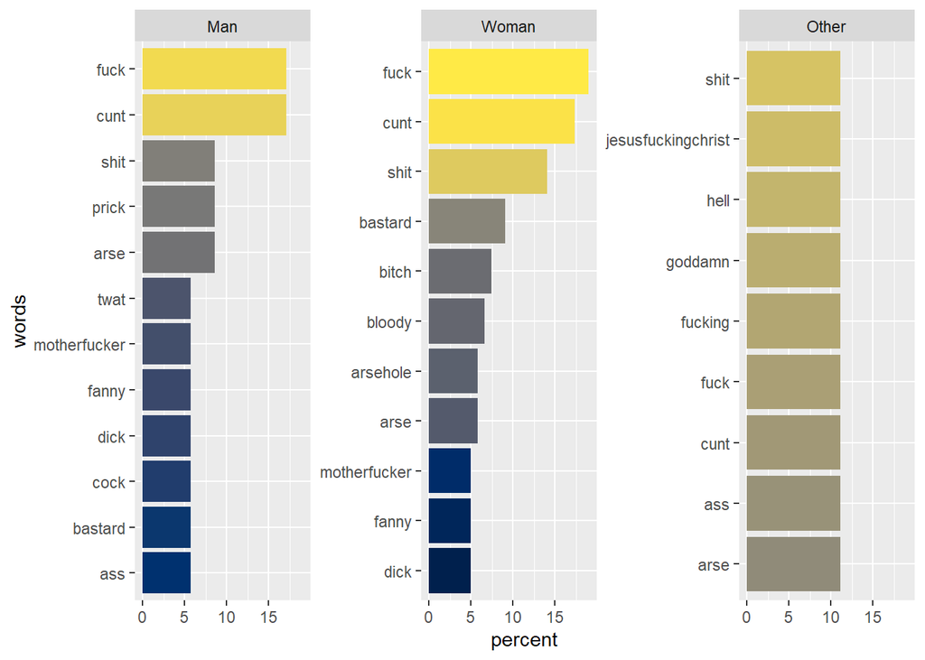

## Word cloud - men

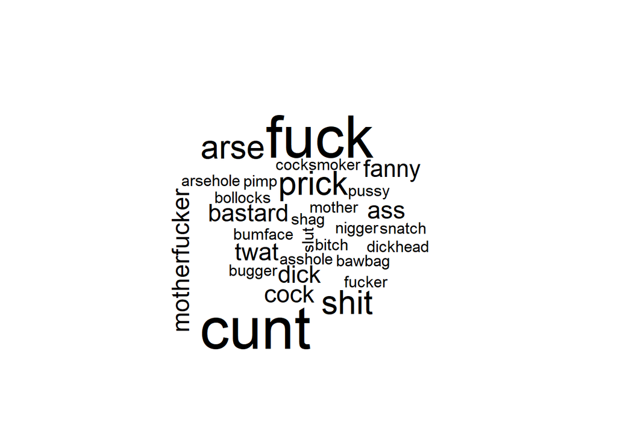

## Word cloud - women

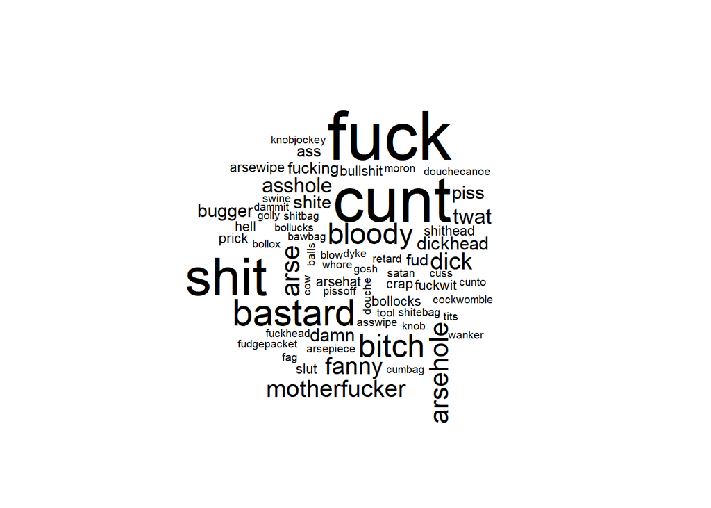

## Word cloud - non-binary/other

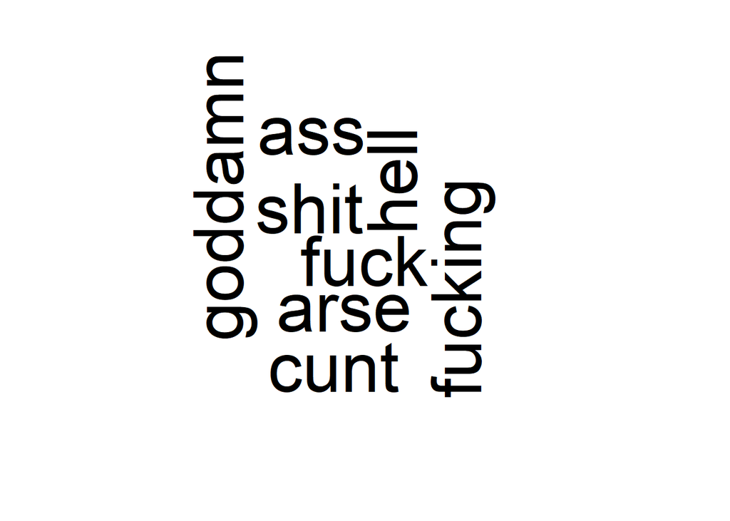